# Decisões Racionais Básicas

Uma **decisão racional** é um acionamento resultante de raciocínio.

Assumimos que um processo de decisão racional adequado nos leva a tomar decisões razoáveis. O exemplo abaixo mostra uma representação possível para um processo de decisão de uma situação tão corriqueira quanto o sair ou não sair em ambientes abertos quando está chovendo:

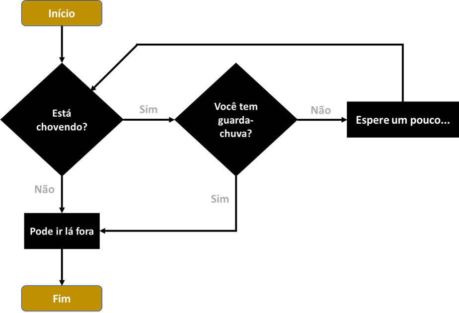

```python
from IPython.display import Image
Image("processo_sairChuva.png")
```

É claro que o processo de raciocínio e decisão humano é muito mais complexo do que o esquema acima, pois envolve a dinâmica sináptica cerebral, incluindo efeitos de emoções etc. A Psicologia Comportamental inclusive nos diz que nossas decisões nem são tão racionais quanto tendemos a pensar. Mas você deve admitir que o tipo de esquema acima é uma maneira conveniente de representar, idealizar, modelar e sistematizar uma decisão racional. Na verdade, ele é o mais básico e largamente usado.

Nosso principal objetivo ao usarmos computadores é a automação de tarefas, das mais simples e enfadonhas às mais complexas e sofisticadas. Claro, quando estamos diante de tarefas com algum grau de complexidade e sofisticação, é preciso dar à máquina a liberdade de tomar algumas decisões. E é aí que entra a representação de decisão racional vista acima. Como ela é em suma um encadeado de operações lógicas e execuções de instruções imperativas (as ações), podemos traduzí-la em código de máquina. Segue abaixo um exemplo de uma decisão que pode ser automatizada por máquina:

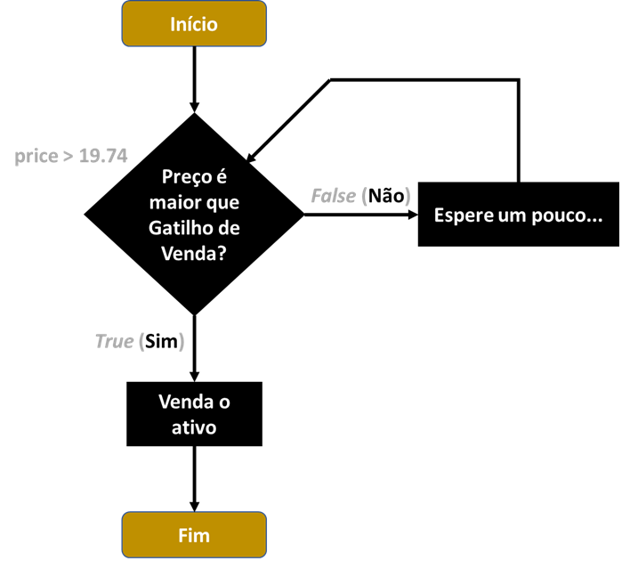

```python
from IPython.display import Image
Image("processo_trade.png")
```

Como já investigamos as Operações Lógicas Booleanas, resta-nos estudar Fluxo de Processos e Operações de Controle de Fluxo (que está dentro de Fluxo de Processos). É o que faremos em seguida.

# Fluxo de Processos

Fluxo de Processos refere-se à ordem em que as atividades são dispostas para que se atinja um fim, sendo a própria definição de Algoritmo (passos ordenados para se chegar a um fim). No ambito de programação de computadores, refere-se à ordem em que as instruções são avaliadas ou executadas.

## Operações Sequenciais

É um exemplo de Operação Sequencial:

```python
# Sejam dois preços, o de compra e o de venda de um determinado ativo financeiro, deseja-se calcular o retorno [u.m.] da operação.
price_buy = float(input('Insira o Preço de Compra:'))
price_sell = float(input('Insira o Preço de Venda:'))
return_cash = price_sell - price_buy
# Repare que todos os comandos são dados na sequência, um por linha, e não há outra ordem possível de execução destes comandos.
```

```python
return_cash
```

[output not shown]

## Operações de Controle de Fluxo

Veremos aqui alguns exemplos, tanto de Operações Condicionais, quanto de Operações Iterativas.

### Operações Condicionais

Em linguagens de programação, as palavras-chave **se**, **então** e **senão** costumam ser substituídos pelos seus termos equivalentes em inglês: *if*, *then*, e *else*.

No caso do Python em específico, o *then* é substituído por *:*.

Vejamos um exemplo:

```python
# Partindo do exemplo anterior, em que calculamos o retorno [u.m.] para uma posição fechada em um ativo, agora queremos decidir qual a
# caracterização daquele retorno, se deu prejuízo ou não.
price_buy = float(input('Insira o Preço de Compra:'))
price_sell = float(input('Insira o Preço de Venda:'))
return_cash = price_sell - price_buy
if return_cash >= 0:
    print('Não prejuízo.')
else:
    print('Prejuízo.')
# Obs: A função print (imprimir), como o próprio nome já diz, serve para imprimir o resultado no console (local da interface onde o
# interpretador mostra seus resultados).
```

Repare que o programa acima só retorna as rasultantes 'Prejuízo.' e 'Não Prejuízo.'. Mas digamos que estas duas resultantes não são suficientes, pois gostaríamos de saber se houve 'Prejuízo.', 'Nem lucro, nem prejuízo.' e 'Lucro.'.

Quando temos mais do que duas resultantes possíveis, nossa estrutura de operações condicionais necessitam mais do que o *if* e o *else* apenas. É para estas situações que existe o *else if* usado na maioria das linguagens de programação. Em Python, *else if* é escrito de maneira contraída: *elif*.

Veja o exemplo a seguir, uma evolução do exemplo anterior.

```python
price_buy = float(input('Insira o Preço de Compra:'))
price_sell = float(input('Insira o Preço de Venda:'))
return_cash = price_sell - price_buy
if return_cash > 0:
    print('Lucro.')
elif return_cash == 0:
    print('Nem lucro, nem prejuízo.')
else:
    print('Prejuízo.')
```

Uma alternativa à solução acima apresentada seria a utilização de um "*nested if*" (*if* aninhado), que nada mais é do que um if dentro do outro.

Vejamos o exemplo a seguir:

```python
price_buy = float(input('Insira o Preço de Compra:'))
price_sell = float(input('Insira o Preço de Venda:'))
return_cash = price_sell - price_buy
if return_cash >= 0:
    if return_cash > 0:
        print('Lucro.')
    else:
        print('Nem lucro, nem prejuízo.')
else:
    print('Prejuízo.')
```

Apenas para não parecer que *print()* é a única opção de comandos subordinados (na verdade, qualquer comando pode estar lá), segue um exemplo em que ao invés de pedirmos para imprimir o resultado, o armazenamos dentro de uma variável:

```python
price_buy = float(input('Insira o Preço de Compra:'))
price_sell = float(input('Insira o Preço de Venda:'))
return_cash = price_sell - price_buy
if return_cash >= 0:
    if return_cash > 0:
        return_feature = 'Lucro.'
    else:
        return_feature = 'Nem lucro, nem prejuízo.'
else:
    return_feature = 'Prejuízo.'
```

```python
return_feature
```

[output not shown]

*if*, *elif* e *else* podem ter vários comandos subordinados a eles (não somente um como nos exemplos acima), como veremos em exemplos mais complexos à frente.